# Preprocessing danych

Zuzanna Chaniewska, Agata Ćwikła

2026-04-11

# Cel i opis projektu

Celem projektu był proprocessing danych `cars` za pomocą języka R. W ramach wykonywania zadania przeanalizowano strukturę danych, następnie oczyszczono je oraz dokonano imputacji brakujących danych.

# Dane cars

W pierwszym kroku zapoznano się ze zbiorem danych. Poniżej przedstawiono statystyki ogólne zbioru oraz jego strukturę.

```
##       mpg            cylinders      cubicinches              hp
##  Min.   :   0.00   Min.   : 0.000   Length:261         Min.   :-125.0
##  1st Qu.:  16.70   1st Qu.: 4.000   Class :character   1st Qu.:  75.0
##  Median :  22.00   Median : 6.000   Mode  :character   Median :  95.0
##  Mean   :  31.96   Mean   : 5.758                      Mean   : 115.8
##  3rd Qu.:  29.00   3rd Qu.: 8.000                      3rd Qu.: 139.0
##  Max.   :1236.00   Max.   :42.000                      Max.   :1175.0
##  NA's   :2         NA's   :1
##   weightlbs           time.to.60          year         brand
##  Length:261         Min.   :  1.60   Min.   :1971   Length:261
##  Class :character   1st Qu.: 14.00   1st Qu.:1974   Class :character
##  Mode  :character   Median : 16.00   Median :1977   Mode  :character
##                     Mean   : 16.26   Mean   :1977
##                     3rd Qu.: 17.00   3rd Qu.:1980
##                     Max.   :221.00   Max.   :1983
##                                      NA's   :1
```

```
## 'data.frame':    261 obs. of  8 variables:
##  $ mpg        : num  14 31.9 17 15 30.5 0 13 14 25.4 37.7 ...
##  $ cylinders  : int  8 4 8 8 4 8 8 8 5 4 ...
##  $ cubicinches: chr  " 350" " 89" " 302" " 400" ...
##  $ hp         : int  165 71 140 150 63 1125 158 215 77 62 ...
##  $ weightlbs  : chr  " 4209" " 1925" " 3449" " 3761" ...
##  $ time.to.60 : num  12 14 11 10 17 17 13 9 20 17 ...
##  $ year       : int  1972 1980 1971 1971 1978 1980 1974 1971 1980 1982 ...
##  $ brand      : chr  " US." " Europe." " US." " US." ...
```

- **mpg** - spalanie silnika w milach na galon
- **cylinders** - liczba cylindrów silnika
- **cubicinches** - pojemność skokowa silnika w calach sześciennych
- **hp** - moc silnika w koniach mechanicznych
- **weightlbs** - masa samochodu w funtach
- **time.to.60** - czas przyspieszenia samochodu do 60 mil/h
- **year** - rok produkcji
- **brand** - pochodzenie.

## Poprawa typów danych

Kolumny `cubicinches` oraz `weightlbs` zostały błędnie wczytane jako typ `character` ze względu na obecność wartości zawierających znaki literowe (np. “a70”, “20d19”). Znaki literowe usunięto za pomocą wyrażeń regularnych, a następnie przekonwertowano kolumny do typu `numeric`.

```r
cars$cubicinches <- as.numeric(gsub("[a-zA-Z]", "", cars$cubicinches))
cars$weightlbs <-  as.numeric(gsub("[a-zA-Z]", "", cars$weightlbs))
str(cars) #sprawdzenie czy konwersja się powiodła
```

```
## 'data.frame':    261 obs. of  8 variables:
##  $ mpg        : num  14 31.9 17 15 30.5 0 13 14 25.4 37.7 ...
##  $ cylinders  : int  8 4 8 8 4 8 8 8 5 4 ...
##  $ cubicinches: num  350 89 302 400 98 350 351 440 183 89 ...
##  $ hp         : int  165 71 140 150 63 1125 158 215 77 62 ...
##  $ weightlbs  : num  4209 1925 3449 3761 2051 ...
##  $ time.to.60 : num  12 14 11 10 17 17 13 9 20 17 ...
##  $ year       : int  1972 1980 1971 1971 1978 1980 1974 1971 1980 1982 ...
##  $ brand      : chr  " US." " Europe." " US." " US." ...
```

Dzięki temu wszystkie dane oprócz “brand” są danymi numerycznymi.

## Wizualizacja surowych danych

W celu przedstawienia wykresów w bardziej uporządkowany sposób stworzono nową funkcję.

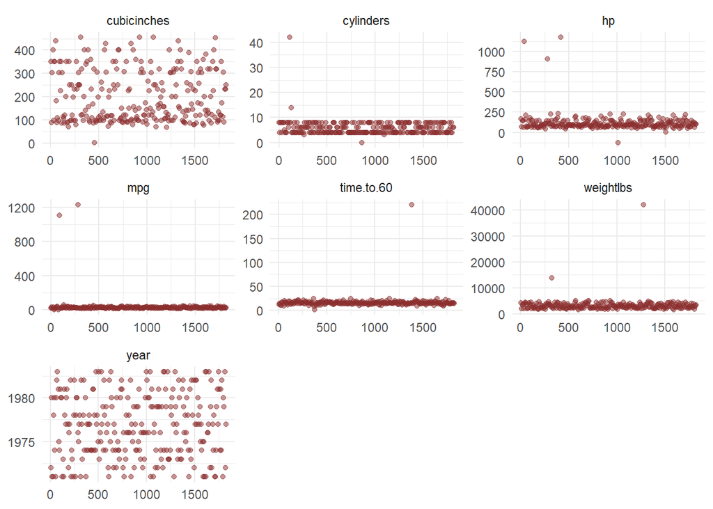

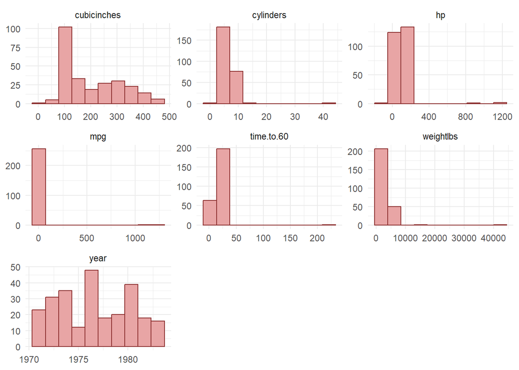

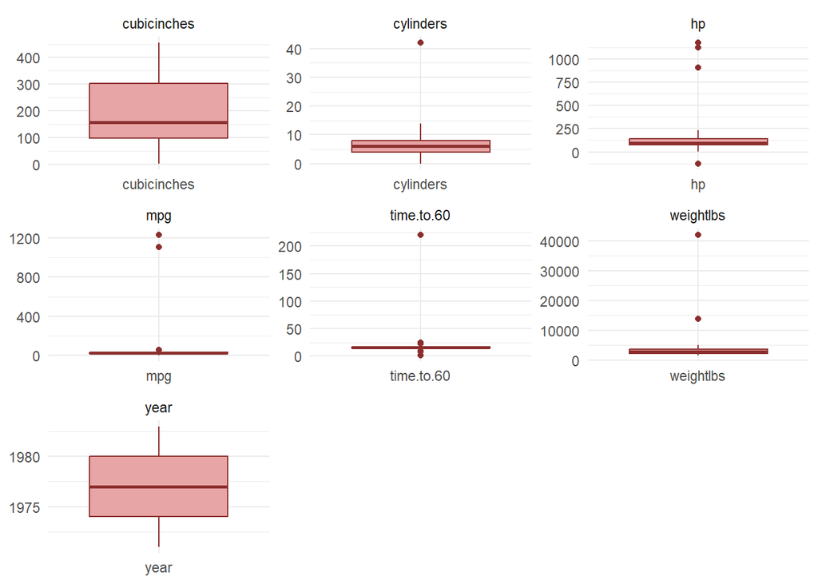

```r
make_plots <- function(df, cols, fill_col = "lightgreen", border_col = "#555555"){ #kolory defaultowe

  data_long <- df %>%
    select(all_of(cols)) %>%
    pivot_longer(cols = everything(), #zamiana na format długi
                 names_to = "variable",
                 values_to = "value")

  # scatterplot
  p1 <- data_long %>%
    ggplot(aes(x = seq_along(value), y = value)) +
    geom_point(alpha = 0.5, color = border_col) +
    facet_wrap(~variable, scales = "free") +
    labs(x=NULL, y=NULL) +
    theme_minimal()

  # histogramy
  p2 <- data_long %>%
    ggplot(aes(x = value)) +
    geom_histogram(bins = 10, fill = fill_col, color = border_col) +
    facet_wrap(~variable, scales = "free") +
    labs(x=NULL, y=NULL) +
    theme_minimal()

  # boxploty
  p3 <- data_long %>%
    ggplot(aes(x = variable, y = value)) +
    geom_boxplot(fill = fill_col, color = border_col) +
  facet_wrap(~variable, scales = "free")+
    labs(x=NULL, y=NULL) +
    theme_minimal()

  list(
    scatter = p1,
    histogram = p2,
    boxplot = p3
  )
}
```

Dodatkowo wykonano wykres na podstawie parametru “brand”.

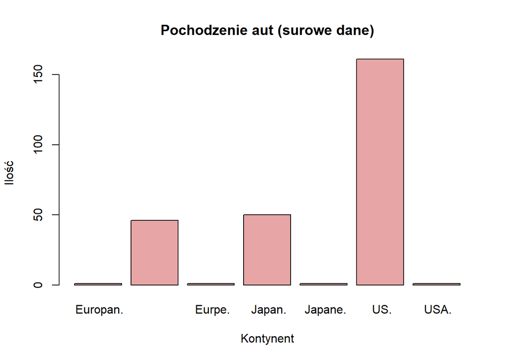

```r
plot(as.factor(cars$brand),
     main = "Pochodzenie aut (surowe dane)",
     xlab = "Kontynent",
     ylab = "Ilość",
     col = "#e8a5a5")
```

Dzięki wizualizacji danych łatwo zauważono, że występują niespójności lub literówki w kolumnie “brand”, natomiast w danych numerycznych znajdują się wartości sprzeczne z logiką i inne błędy, z których należy oczyścić zbiór.

# Czyszczenie danych

## Poprawa spójności w nazewnictwie brand

```r
brand_cut <- str_remove(cars$brand," ") #usunięcie spacji
brand_cut <- str_remove(brand_cut,"\\.") #kropka w notacji regex oznacza dowolny znak, dlatego należy użyć \\ aby została potraktowana jako kropka
brand_clean <- ifelse(brand_cut %in% c("Europan", "Eurpe"), "Europe",
           ifelse(brand_cut == "Japane", "Japan",
           ifelse(brand_cut == "USA", "US", brand_cut)))
```

### Wizualizacja

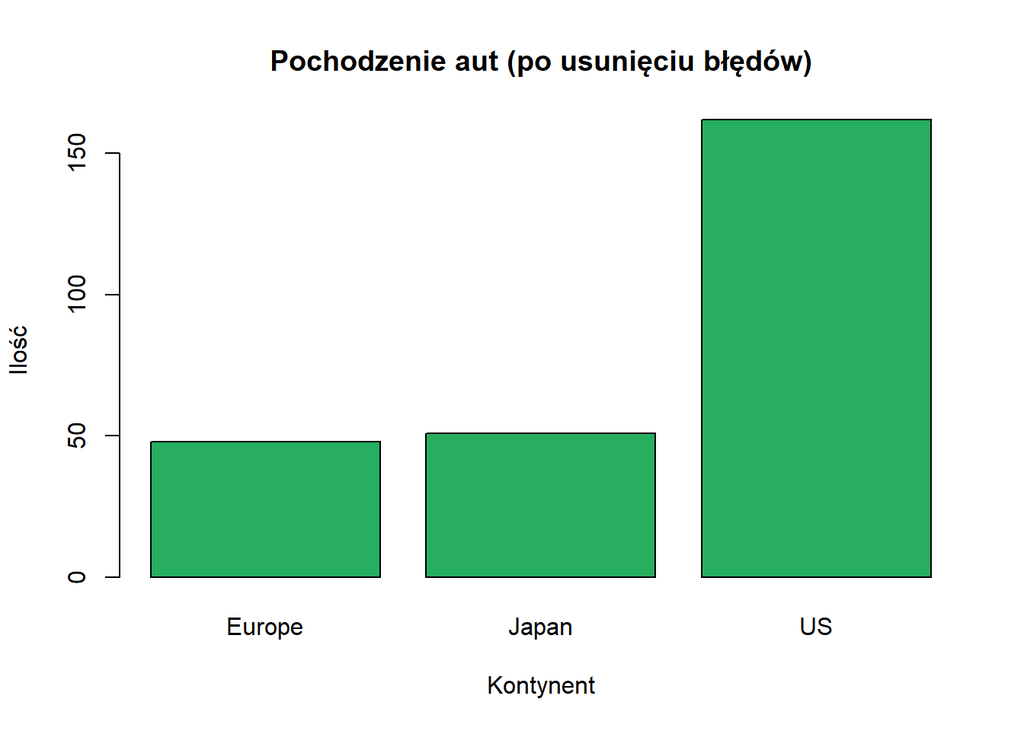

```r
plot(as.factor(brand_clean),
       main = "Pochodzenie aut (po usunięciu błędów)",
       xlab = "Kontynent",
       ylab = "Ilość",
       col = "#27ae60")
```

## Usuwanie wartości sprzecznych z logiką

Na tym etapie przeanalizowano, jakie wartości są fizycznie niemożliwe dla samochodów. Dla każdej zmiennej numerycznej określono dopuszczalny zakres wartości, na podstawie wiedzy własnej lub znalezionej w dostępnych źródłach informacji, pasujący do samochodów osobowych z lat 1971–1983:

- mpg – wartości spoza zakresu (5, 60) są mało prawdopodobne dla spalinowych aut osobowych z badanego okresu
- cylinders – silniki seryjne posiadają od 2 do 12 cylindrów; wartości takie jak 0, 14 czy 42 są błędami
- cubicinches – pojemność poniżej 10 cu in jest niemożliwa; wartość 2.50 to prawdopodobnie literówka zamiast 250
- hp – ujemna moc oraz wartości powyżej 500 KM są fizycznie niemożliwe dla aut osobowych tego okresu
- weightlbs – masa auta osobowego mieści się w przedziale (0, 5000) funtów; wartości takie jak 13755 czy 42135 są błędami
- time.to.60 – czas przyspieszenia 0–60 mph poniżej 5 s lub powyżej 60 s jest niemożliwy dla samochodów osobowych.

Takie obserwacje zastąpiono wartością NA, aby móc później uzupełnić je w procesie imputacji.

```r
mpg_clean <- ifelse(cars$mpg > 5 & cars$mpg < 60, cars$mpg, NA)
cylinders_clean <- ifelse(cars$cylinders >= 2 & cars$cylinders < 12, cars$cylinders, NA)
cubicinches_clean <- ifelse(cars$cubicinches > 10, cars$cubicinches, NA)
hp_clean <- ifelse(cars$hp > 30 & cars$hp < 500, cars$hp, NA)
weightlbs_clean <- ifelse(cars$weightlbs > 0 & cars$weightlbs < 5000, cars$weightlbs, NA)
time.to.60_clean <- ifelse(cars$time.to.60 > 5 & cars$time.to.60 < 60, cars$time.to.60, NA)
```

Utworzono nowy dataframe *cars_clean* zawierający dane oczyszczone z wartości sprzeczynych z logiką.

```r
cars_clean <- data.frame(
  mpg = mpg_clean,
  cylinders = cylinders_clean,
  cubicinches = cubicinches_clean,
  hp = hp_clean,
  weightlbs = weightlbs_clean,
  time.to.60 = time.to.60_clean,
  year = cars$year,
  brand = brand_clean
)
#wyświetlenie ilości braków danych po dotychczasowym przetwarzaniu
na_summary_clean <- colSums(is.na(cars_clean))
na_summary_clean
```

```
##         mpg   cylinders cubicinches          hp   weightlbs  time.to.60
##           6           4           2           5           4           2
##        year       brand
##           1           0
```

### Wizualizacja danych po zastosowaniu przedziałów logicznych

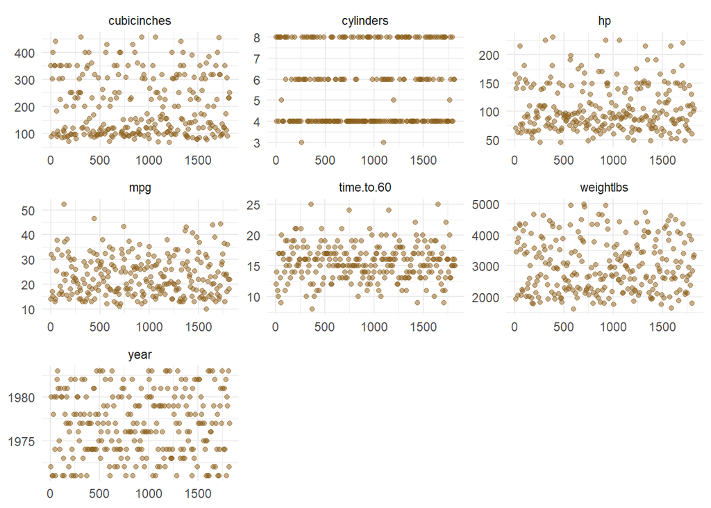

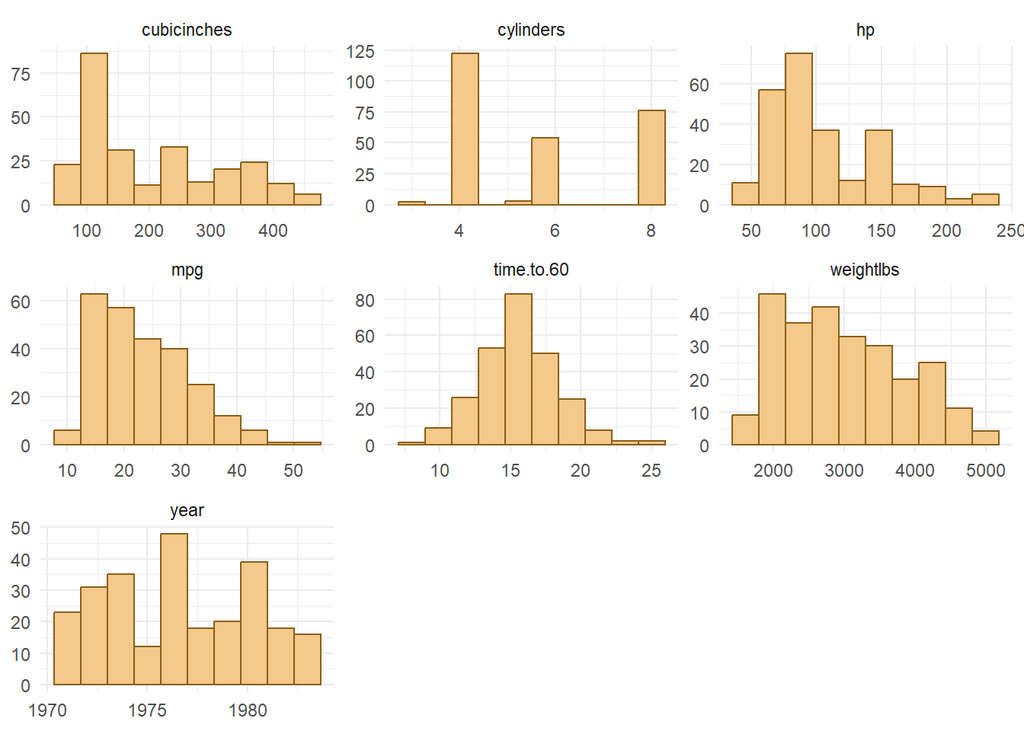

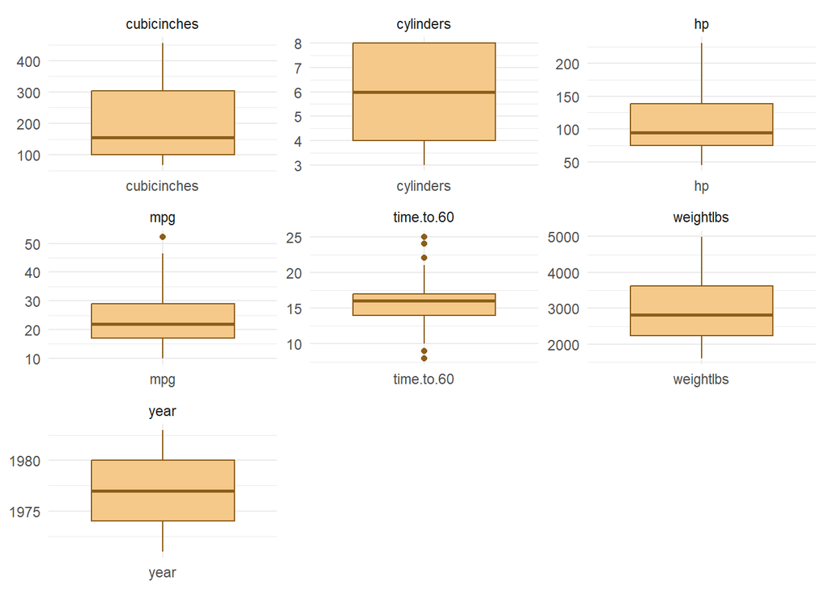

## Usunięcie wartości extremalnych

Rozkłady danych po usunięciu wartości sprzecznych z logiką wyglądają o wiele lepiej. Należy jednak jeszcze usunąć wartości ekstremalne, aby nie zaburzały przyszłego potencjalnego modelu.

Do identyfikacji wartości ekstremalnych zastosowano metodę 1.5 × IQR.Metoda ta polega na wyznaczeniu zakresu międzykwartylowego (IQR), czyli różnicy pomiędzy trzecim a pierwszym kwartylem. Za wartości odstające uznaje się obserwacje znajdujące się poza zakresem:

Q1 − 1.5 × IQR oraz Q3 + 1.5 × IQR.

Metoda IQR jest odporna na wpływ wartości ekstremalnych i dobrze sprawdza się w przypadku danych,które nie mają rozkładu normalnego.

```r
remove_outliers_iqr <- function(x) {
  Q1 <- quantile(x, 0.25, na.rm = TRUE)
  Q3 <- quantile(x, 0.75, na.rm = TRUE)
  IQR_val <- Q3 - Q1

  dolna_granica <- Q1 - 1.5 * IQR_val
  gorna_granica <- Q3 + 1.5 * IQR_val

  # Zwraca NA dla ekstremów, a w przeciwnym razie oryginalną liczbę
  ifelse(x < dolna_granica | x > gorna_granica, NA, x)
}

cars_no_outliers <- cars_clean %>%
  mutate(mpg         = remove_outliers_iqr(mpg),
         cylinders   = remove_outliers_iqr(cylinders),
         cubicinches = remove_outliers_iqr(cubicinches),
         hp          = remove_outliers_iqr(hp),
         weightlbs   = remove_outliers_iqr(weightlbs),
         time.to.60  = remove_outliers_iqr(time.to.60))
```

### Wizualizacja po usunięciu wartości ekstremalnych

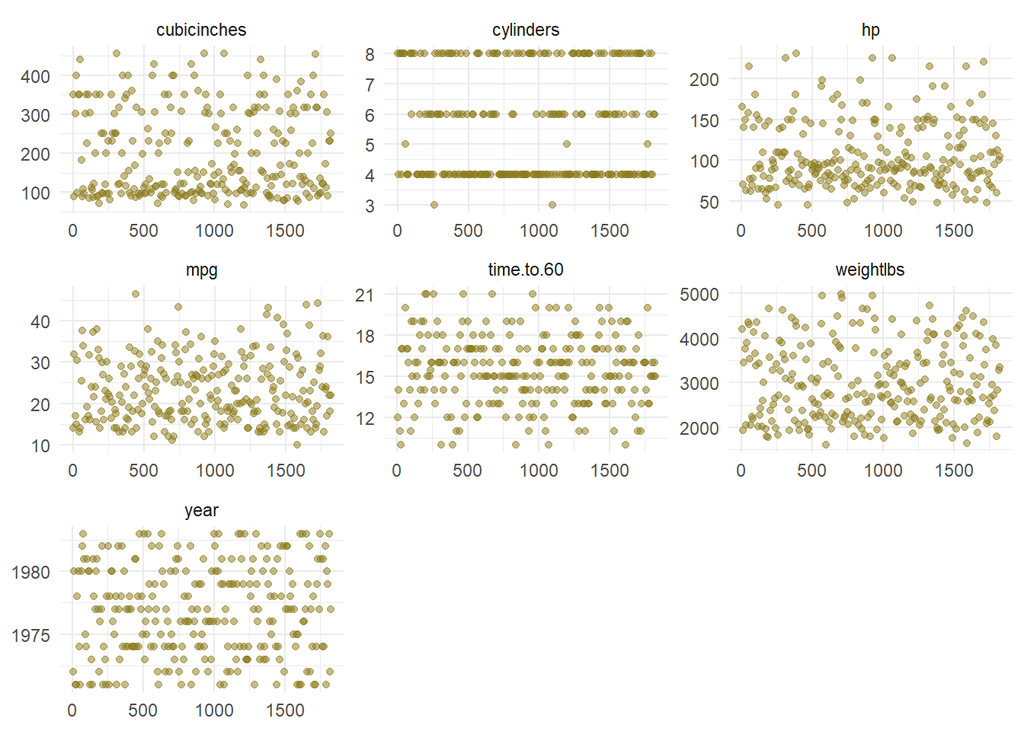

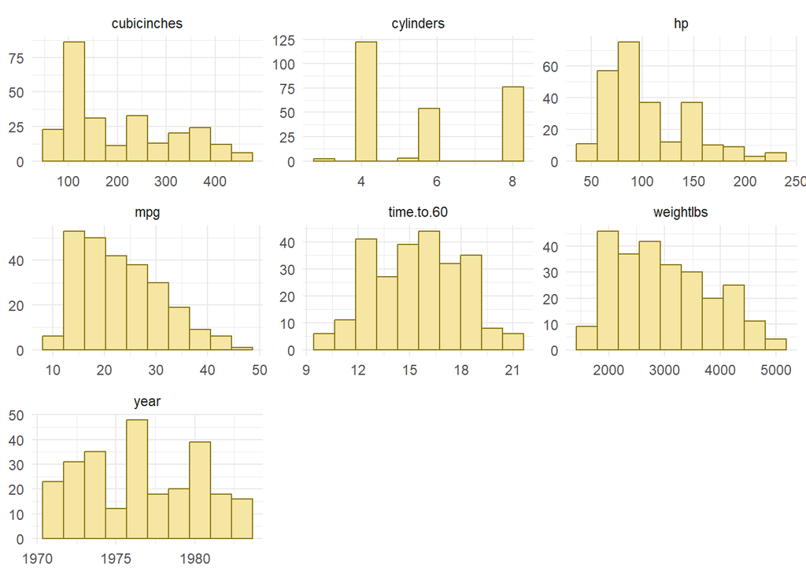

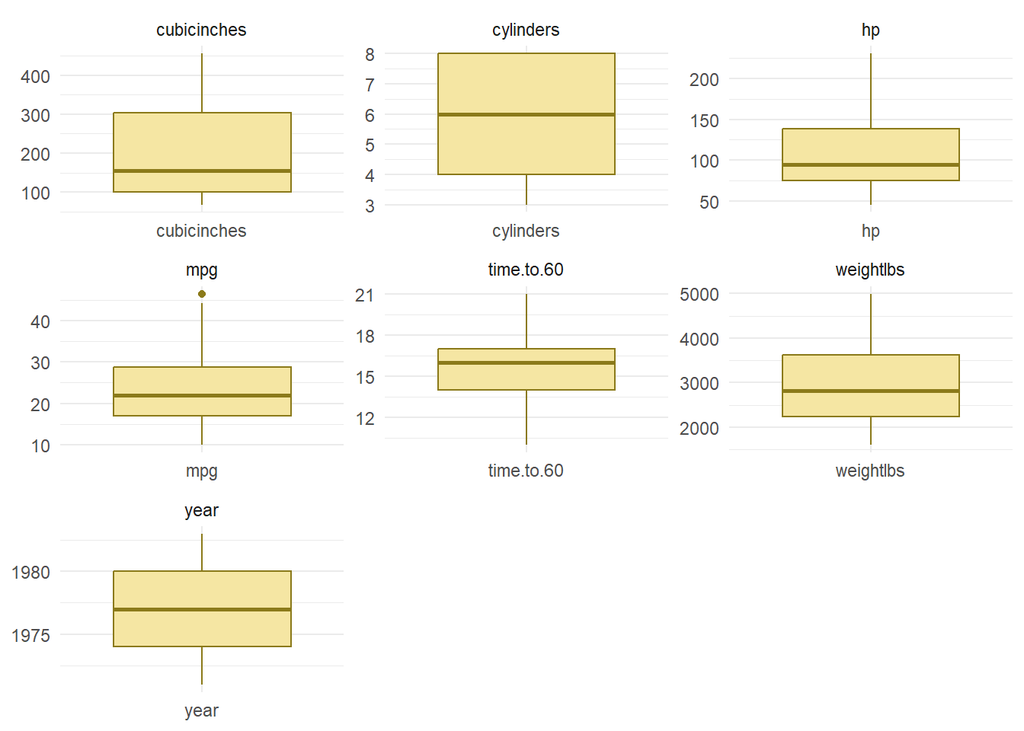

Po zastosowaniu testu 1,5 IQR w zmiennej mpg pozostała jedna wartość odstająca (~50 mpg). Ze względu na asymetryczny rozkład zmiennej oraz fakt, że wartość ta jest teoretycznie możliwa dla małych aut europejskich i japońskich z lat 70./80., zdecydowano o jej zachowaniu.

## Sprawdzenie duplikatów

Na koniec etapu czyszczenia danych sprawdzono, czy w zbiorze nie ma duplikatów. Okazało się, że nie ma takich, więc nie trzeba ich usuwać.

```r
any(duplicated(cars_no_outliers))
```

```
## [1] FALSE
```

# Obsługa braków danych

Na początku sprawdzono, w jakich kolumnach i w jakiej liczbie znajdują się brakujących wartości.

```r
na_summary <- colSums(is.na(cars_no_outliers))
na_summary
```

```
##         mpg   cylinders cubicinches          hp   weightlbs  time.to.60
##           7           4           2           5           4          12
##        year       brand
##           1           0
```

Przy uzupełnianiu brakujących wartości zamiast wyliczać dane na podstawie całego zbioru, zastosowano podejście oparte na podzbiorach danych. Dane uzupełniano wartością mediany z danego podzbioru.

## Imputacja brakującego roku

Brakującą wartość w kolumnie “year” uzupełniono na podstawie mediany lat dla samochodów z tej samej kategorii “brand”.

```r
cars_imputed <- cars_no_outliers %>%
  group_by(brand) %>%
  mutate(year = ifelse(is.na(year), round(median(year, na.rm = TRUE)), year)) %>%
  ungroup()
```

## Imputacja pozostałych danych

Pozostałe dane ilościowe uzupełniono podobną metodą, dodatkowo rozszerzając grupowanie danych o kolumnę `year`. Wyjątkiem jest zmienna `time.to.60`, która dla jednego podzbioru wyznaczonego przez grupowanie po `brand` i `year` składa się w całości z wartośći `NA`, przez co mediana zwraca `NaN`. Z tego powodu dla tej zmiennej zastosowano grupowanie po `brand` i `cylinders`, ponieważ liczba cylindrów bezpośrednio wpływa na wydajność silnika, a tym samym na czas przyspieszenia.

```r
cars_imputed <- cars_imputed %>%
  group_by(brand, year) %>%
  mutate(
    mpg_imp = if_else(
      is.na(mpg),
      median(mpg, na.rm = TRUE),
      mpg
    ),
    cylinders_imp = if_else(
      is.na(cylinders),
      median(cylinders, na.rm = TRUE),
      cylinders
    ),
    cubicinches_imp = if_else(
      is.na(cubicinches),
      median(cubicinches, na.rm = TRUE),
      cubicinches
    ),
    hp_imp = if_else(
      is.na(hp),
      median(hp, na.rm = TRUE),
      hp
    ),
    weightlbs_imp = if_else(
      is.na(weightlbs),
      median(weightlbs, na.rm = TRUE),
      weightlbs
    )
  ) %>%
  ungroup() %>%
  group_by(brand, cylinders) %>%
  mutate(
    time.to.60_imp = if_else(
      is.na(time.to.60),
      median(time.to.60, na.rm = TRUE),
      time.to.60
    )
  ) %>%
  ungroup()
```

Jedyną kolumną, dla której można by rozważyć imputację za pomocą średniej, jest `time.to.60`, ponieważ jej rozkład najbardziej przypomina rozkład normalny. Po porównaniu wyników obu metod stwierdzono jednak, że różnica między wynikami uzyskanymi za pomocą średniej a tymi uzyskanymi za pomocą mediany jest na tyle mała, że ostatecznie zachowano spójność metodyki i zastosowano medianę dla wszystkich zmiennych.

```r
# porównanie średniej i mediany dla time.to.60 przy imputacji grupowej
time_comparison <- cars_no_outliers %>%
  group_by(brand, year) %>%
  mutate(
    time.to.60_mean   = if_else(is.na(time.to.60),
                                mean(time.to.60, na.rm = TRUE),
                                time.to.60),
    time.to.60_median = if_else(is.na(time.to.60),
                                median(time.to.60, na.rm = TRUE),
                                time.to.60)
  ) %>%
  ungroup()

#Porównanie średniej i mediany dla zmiennej time.to.60
c(srednia = mean(cars_no_outliers$time.to.60, na.rm = TRUE),
  mediana = median(cars_no_outliers$time.to.60, na.rm = TRUE))
```

```
##  srednia  mediana
## 15.43534 16.00000
```

Na koniec utworzono ostateczny dataframe zawierający oczyszczone dane z uzupełnionymi brakującymi wartościami.

```r
cars_final <- cars_imputed %>%
  select(
    mpg = mpg_imp,
    cylinders = cylinders_imp,
    cubicinches = cubicinches_imp,
    hp = hp_imp,
    weightlbs = weightlbs_imp,
    time.to.60 = time.to.60_imp,
    year,
    brand
  )
```

Sprawdzono jeszcze, czy na pewno nie istnieją żadne braki danych w końcowym zbiorze.

```r
na_summary <- colSums(is.na(cars_final))
na_summary
```

```
##         mpg   cylinders cubicinches          hp   weightlbs  time.to.60
##           0           0           0           0           0           0
##        year       brand
##           0           0
```

# Wyniki

Poniżej przedstawiono ostateczne wizualizacje danych numerycznych zbioru danych.

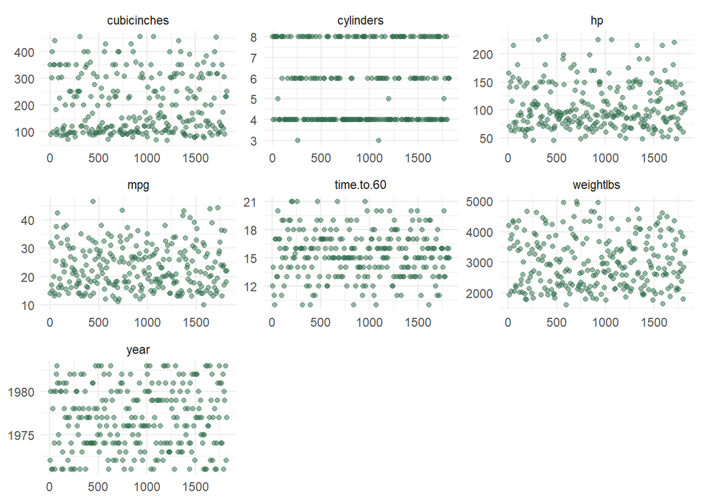

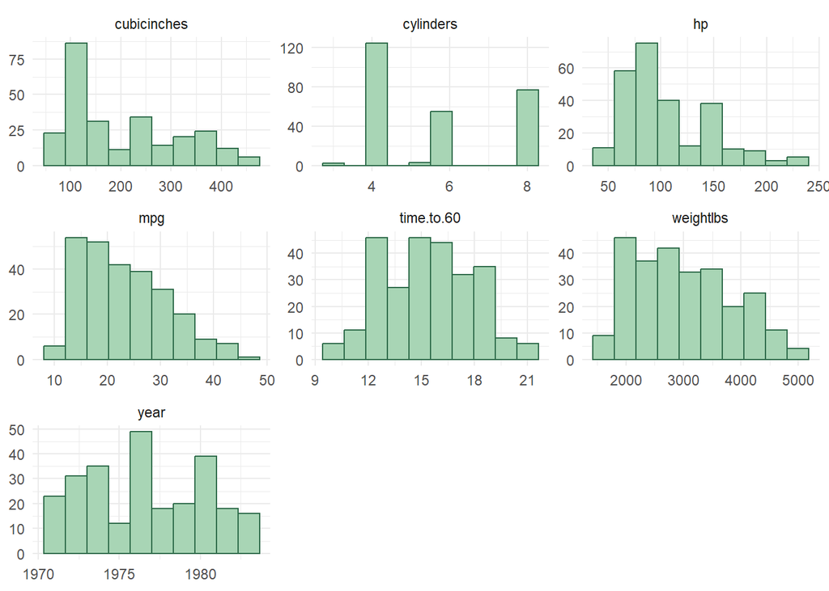

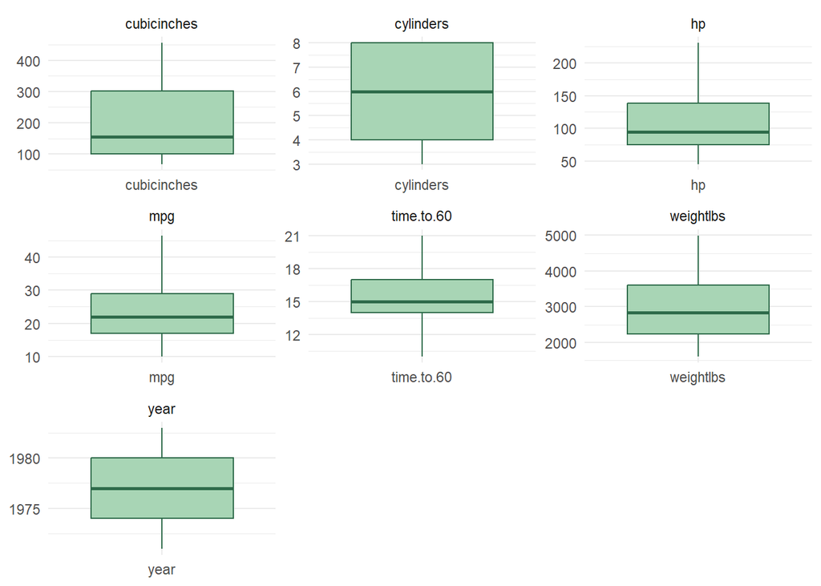

## Interpretacja wyników

Wejściowy zbiór danych `cars` liczył 261 obserwacji oraz 8 zmiennych. Już na etapie wczytania stwierdzono braki wartości w kilku zmiennych, a kolumny `cubicinches` i `weightlbs` wymagały konwersji z typu `character` na `numeric` ze względu na obecność wartości tekstowych w danych, które powinny byc numeryczne.

Czyszczenie logiczne, bazujące na rzeczywistych właściwościach analizowanych pojazdów, ujawniło liczne problemy: wartości ujemne mocy silnika, ekstremalnie wysokie wartości masy i liczby koni mechanicznych oraz fizycznie niemożliwe, takie jak zerowa liczba cylindrów czy czas przyspieszenia do 60 mil/h wynoszący 221 sekund.

Następnie, w celu identyfikacji wartości ekstremalnych, przeprowadzono test 1,5 × IQR. Największy wpływ miał on na zmienną `time.to.60`, dla której usunięto aż 10 dodatkowych obserwacji. W pozostałych zmiennych jedynie `mpg` zyskało jedną dodatkową wartość `NA`. Na tej podstawie można stwierdzić, że zastosowane wcześniej warunki logiczne były wystarczające dla większości zmiennych, natomiast dla `time.to.60` przyjęty przedział okazał się zbyt szeroki w kontekście tego zbioru.

Główną metodą imputacji braków danych było podejście grupowe (group-wise imputation), pozwalające zachować charakterystyczne cechy pojazdów wynikające z miejsca i czasu produkcji. Jedynie w przypadku zmiennej `time.to.60` metoda ta okazała się nieskuteczna — jedna z podgrup składała się w całości z wartości `NA`, przez co mediana zwracała `NaN`. Z tego powodu zmieniono czynnik grupujący z `year` na `cylinders`, jako zmienną bezpośrednio wpływającą na czas przyspieszenia.

Końcowy zbiór `cars_final` zawiera 261 obserwacji bez żadnych braków danych, z wartościami mieszczącymi się w realnych i pasujących do tematyki zbioru zakresach.

## Wnioski

Przeprowadzony preprocessing pozwolił przygotować zbiór danych do dalszej analizy lub budowy modeli statystycznych.

Najważniejsze etapy obejmowały: - poprawę typów danych, - usunięcie błędów logicznych, - identyfikację i eliminację wartości ekstremalnych, - imputację brakujących wartości na podstawie podobnych obserwacji.

Zastosowanie imputacji opartej na podzbiorach danych pozwoliło zachować charakterystyczne cechy samochodów z różnych regionów oraz lat produkcji.

Po zakończeniu preprocessingu końcowy zbiór danych `cars_final` nie zawiera braków danych ani wartości sprzecznych z logiką, co czyni go odpowiednim do budowy modeli predykcyjnych.